# Lecture 8: Customer Lifetime Value

How Much Is Each Customer Worth Over the Next 12 Months?

## Every model serves a marketing decision

Win customers

CMO: “Which channels and touchpoints are actually bringing customers in?”

- L01A/B testingDid it work?
- L03Marketing mix modelingHow much?
- L06Multi-touch attributionHow much?

Set the offer

Head of pricing: “What should we charge, and which features matter?”

- L02Price elasticityHow much?
- L09Conjoint analysisWhat do they want?

The marketing decisionStart from what the business is asking

Keep customers

Head of retention: “Who is leaving, when, and who should get the save offer?”

- L04Survival analysisWhat next?
- L05Markov chainsWhat next?
- L07Uplift modelingDid it work?

Value customers

CFO: “What is a customer worth to us?”

- L08Customer lifetime value · todayWhat next?

Plan ahead

Operations: “What will next quarter look like?”

- L10Demand forecastingWhat next?

**Question type:**Did it work? causal effectHow much? how much X moves YWhat do they want? preferencesWhat next? prediction

## Motivating Problem

**Tip**

**Setting:** A firm seeks to estimate expected future customer value from observed transaction histories. Your CEO asks: “What’s the average customer worth?” Your CFO asks: “How much can we spend to acquire a customer?” Both questions require CLV — but they need different breakdowns.

**Learning Objectives**

- Compute a simple undiscounted CLV
- Interpret P(alive) from a BG/NBD model
- Explain the Gamma-Gamma independence assumption
- Use LTV:CAC ratios to evaluate acquisition channel efficiency
- Identify when CLV estimates are unreliable

## Simple CLV: The Building Block

You need this

No probability model needed for the basic calculation:

$$\text{CLV}_{12} = E[\text{transactions in next 12m}] \times E[\text{spend per transaction}]$$

**Example:** $E[\text{trans}] = 3.2$, $E[\text{spend}] = \$55$

$$\text{CLV}_{12} = 3.2 \times 55 = \mathbf{\$176}$$

CLV₁₂ is the first 12 months of *lifetime* value, and the CLV this course uses throughout. (A full lifetime CLV is optional background in the note.)

**Tip**

This assumes transaction frequency and spend are known (historical averages).  
BG/NBD predicts *future* transaction frequency — that’s the upgrade.

**Warning**

BG/NBD’s E[transactions] = P(alive) × E[transactions | still active], so it **already includes P(alive)**. The CLV₁₂ built on it is already an expected value: never multiply it by P(alive) again. Multiply P(alive) only by a value *if still active*.

## Mean CLV vs Median CLV

A CLV distribution is almost never symmetric, so the *average* customer and the *typical* customer are two different people.

**Median** = the middle value after sorting — half at or below, half at or above. Odd count: the middle value. Even count: the average of the two middle values (`Series.median()`).

Five customers: $25, $40, $60, $85, $540

- median = **$60** · mean = 750/5 = **$150**
- make the top customer $5,400 → mean **$1,122**, median still **$60**

**Tip**

**mean > median → right-skewed** (the normal case for CLV): the mean is pulled up by a small top tail, so it *overstates* the typical customer. **mean ≈ median** → symmetric. **mean < median** → left-skewed.  
Quote the median when asked what “a customer” is worth; use the mean when you need a total.

## Why We Need BG/NBD

**Problem:** We don’t know which customers are still active.

A customer who bought 12 times, then nothing for 18 months — are they still a customer?

BG/NBD explicitly models:

1. **Purchase process:** How frequently does this customer buy (when alive)?
2. **Dropout process:** After each repeat purchase, does this customer “die” (churn permanently)?

**Tip**

**Identification challenge:** A customer with high historical purchase frequency and a long recent silence may have churned or may be in a temporarily extended inter-purchase interval. BG/NBD decomposes this uncertainty via the $P(\text{alive})$ estimator.

## Two Models, Multiplied

You need this

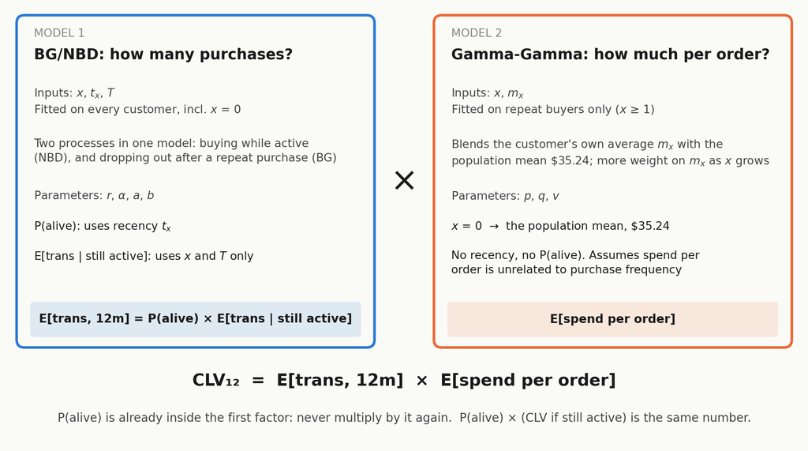

Gamma-Gamma is **not part of** BG/NBD: they are fitted separately, on different customers, and only their outputs are multiplied.

## BG/NBD Inputs

Only three variables needed per customer:

| Variable | Meaning |
| --- | --- |
| $x$ | Number of repeat transactions in observation window |
| $t_x$ | Time of last transaction |
| $T$ | Length of observation window |

**No demographics required.**  
The model infers activity status purely from purchase timing.

## P(alive): The Core Output

Background: why it works, not on quizzes

$$P(\text{alive} \mid x, t_x, T) = \frac{1}{1 + \dfrac{a}{b + x - 1}\left(\dfrac{\alpha + T}{\alpha + t_x}\right)^{r + x}} \quad (x \ge 1;\ \text{exactly 1 if } x = 0)$$

**How to read it:**

| P(alive) | Interpretation | Action |
| --- | --- | --- |
| > 0.80 | Almost certainly still active | May not need an offer (Sure Thing?) |
| 0.20 – 0.80 | Uncertain — could be in long gap | Something to save: test an offer here first |
| < 0.20 | Likely churned | Little left to save |

P(alive) says who is still **there**, not who an offer **changes**. That is uplift (L07).

**One-time buyers (x = 0) get P(alive) = 1** because the model can’t let them drop out before a repeat purchase, not because they are still active. Don’t put them in the top row; read their E[transactions] instead (≈ 0.30 after 24 quiet months).

**Warning**

P(alive) = 0.08 with 12 past purchases does NOT mean this customer is loyal.  
It means 92% probability they have already left.

## Recency Is Read Against Frequency

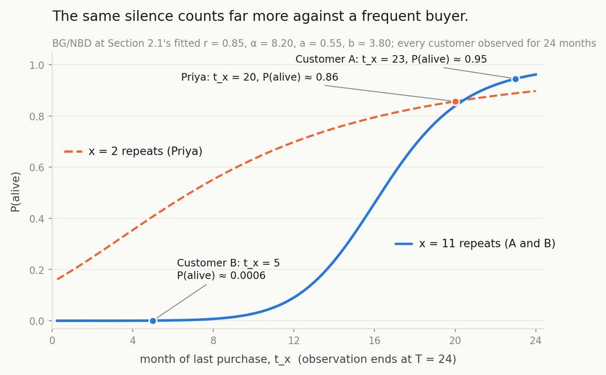

Customers A and B: 12 purchases each, last at month 23 vs month 5. The same months of silence cost a frequent buyer far more P(alive).

## Gamma-Gamma: The Assumption You Must Check

You need this

Gamma-Gamma predicts **spend per order**. How many orders is BG/NBD’s job. CLV₁₂ multiplies the two, which is only safe if:

$$\text{Transaction frequency} \perp \text{Spend per transaction}$$

**Check:** `pearsonr(frequency, avg_order_value)` among repeat buyers.

| \|correlation\| | Verdict |
| --- | --- |
| < 0.2 | holds: use as-is |
| 0.2 – 0.3 | grey zone: usable, but say so |
| ≥ 0.3 | material violation |

**Warning**

**Negative** (frequent buyers spend less per order): CLV for high-frequency customers is **overestimated**. **Positive**: it is **underestimated**.

## Optional: How Gamma-Gamma Predicts Spend

Background: why it works, not on quizzes

**Inputs:** $x$ repeat purchases and $m_x$, the customer’s average over **repeat** orders only; $p, q, v$ are fitted on repeat buyers. No recency, no P(alive).

**Two stacked Gammas:** order spend varies around the customer’s typical spend (shape $p$, *not* the dropout probability), and typical spend varies across customers (shape $q$, scale $v$).

**Few orders → pulled toward the population mean** $p\,v/(q-1)$: the prediction blends $m_x$ with it, trusting $m_x$ more as $x$ grows. Two orders are weak evidence; twelve are strong.

## Optional: Gamma-Gamma’s Pull Toward the Mean

Background: why it works, not on quizzes

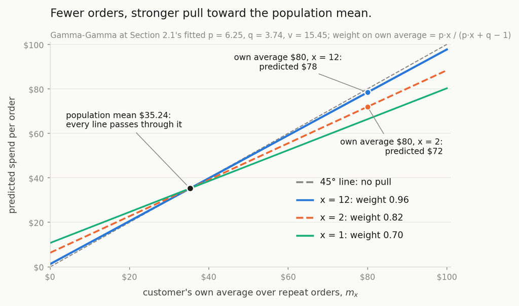

**One-time buyers (x = 0) still get a CLV.** Spend/order is the population mean, $35.24, for all of them, but expected purchases fall with time since their one order: CLV₁₂ ≈ $29 if they bought 3 months ago, ≈ $11 if 24 months ago. “Repeat buyers only” is about *fitting* Gamma-Gamma, not who gets a prediction.

## LTV:CAC Ratio

You need this

$$\text{LTV:CAC} = \frac{\text{Expected CLV}}{\text{Customer Acquisition Cost}}$$

| Channel | CLV | CAC | LTV:CAC | Decision |
| --- | --- | --- | --- | --- |
| Paid Social | $85 | $35 | 2.43 | Borderline — watch |
| Organic | $210 | $8 | 26.3 | Efficient; check headroom before adding spend |
| Paid Search | $130 | $45 | 2.89 | Just under 3 — check payback |

**Tip**

**Empirical benchmark:** LTV:CAC > 3 is commonly cited as a sustainable acquisition threshold. However, this benchmark varies by industry, margin structure, and discount rate. Channel-level segmentation is necessary because aggregate CAC obscures within-channel heterogeneity.

**Warning**

**CLV:CAC is an average; budget moves on the margin.** Where the *next* dollar goes is MMM’s marginal ROI (L03). A 26:1 organic channel may be saturated: fund a channel while the *next* customer costs less than they are worth.

## The Retention Rule (L04 · L05 · L07 · L08)

Spend on keeping a customer when **(change the offer causes) × (worth if kept) > cost**

| Lecture | What it tells you | Its part in the rule |
| --- | --- | --- |
| L04 Survival · L05 Markov | Who is at risk, and how soon | None directly: **where and when** to test an offer |
| L08 CLV / P(alive) | Who is still there, and what they are worth | **Worth if kept** (the most retention could recover) |
| L07 A/B test · uplift | Whether the offer changes anything | **Change the offer causes** |

**Warning**

High churn risk, low P(alive) or high CLV is a reason to **look**, not a reason to **spend**.

## Practice: work in pairs (1 of 2)

Answer each one, then mark **Sure** or **Unsure** as you would on the quiz.

**1. True or false?** BG/NBD gives a customer who has bought exactly once a P(alive) of 1.

**2.** The model’s CLV₁₂ for a customer, $E[\text{transactions}] \times E[\text{order value}]$, is $120. Their P(alive) is 0.60. What is their expected 12-month value?

A. $120 B. $72 C. $200 D. $48

**3.** Channel X: CAC = $50, predicted 12-month CLV = $100. Channel Y: CAC = $20, predicted 12-month CLV = $90. Which statement is right?

A. X is the better channel because its customers are worth more  
B. CLV:CAC is 2.0 for X and 4.5 for Y, so Y buys more value per acquisition dollar  
C. CLV:CAC is 0.50 for X and 0.22 for Y, so X is the more efficient channel  
D. Neither channel clears the 3:1 benchmark

Answers in the lecture notes, under “Slide Practice Answers” (numbered to match these slides).

## Practice: work in pairs (2 of 2)

**4. True or false?** Two customers are both observed for 24 months, and both last bought in month 6. The one with 12 repeat purchases has a higher P(alive) than the one with 1.

**5.** Mean 12-month CLV is $180 and median 12-month CLV is $70 across 10,000 customers. The CFO asks what a typical customer is worth, and what the whole base is worth. Which pair do you report?

A. $70 and $700,000  
B. $180 and $1,800,000  
C. $70 and $1,800,000  
D. $180 and $700,000

**6. True or false?** The correlation between purchase frequency and average order value is +0.40. Gamma-Gamma will overestimate CLV for high-frequency customers.

Answers in the lecture notes, under “Slide Practice Answers” (numbered to match these slides).

## Checkpoint

1. $E[\text{trans in 12 months}] = 3.6$, $E[\text{order value}] = \$45$. Compute CLV₁₂ (no discounting).
2. Both observed for 12 months. Customer A: 20 purchases, last 3 months ago. Customer B: 2 purchases, last 2 weeks ago. Who has higher P(alive)?
3. P(alive) = 0.12. If still active, this customer is worth $340 over the next 12 months. What is their **expected** 12-month value?
4. Frequency–spend correlation = −0.52. How does this affect CLV estimates?
5. “Our average CLV is $280, so we can spend $280 to acquire anyone.” What’s wrong?

Answers in the lecture notes, under “Slide Checkpoint Answers” (numbered to match this slide).